# Combined Model and Figure Output

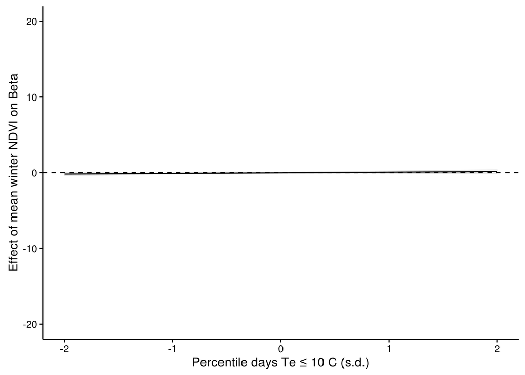

```
## Calculating fixed-effects R2
## Calculating psuedo R2 for numeric response variable
## Calculating Lefcheck (Nakagawa & Schielzeth) marginal and conditional R2
## AIC of best model: 2969.212
## There were 1318 observations and 18 groups in the model.
## Model evaluation completed and tabulated:
```

```
## [[1]]
##         mod.name dAICc.lib dAICCc.con df A.weight.lib D_low D_high R_low
## mod.0      mod.0       0.0        0.0  3            1    NA     NA    NA
## mod.R      mod.R       4.1        5.6  4            0    NA     NA -0.13
## mod.D      mod.D       5.6        7.1  4            0 -0.03   0.11    NA
## mod.D_R  mod.D_R      10.5       14.1  5            0 -0.06   0.10 -0.12
## mod.DR    mod.DR      13.7       20.2  6            0 -0.04   0.14 -0.10
##         R_high DR_low DR_high D_est R_est DR_est       SE_D       SE_R
## mod.0       NA     NA      NA    NA    NA     NA         NA         NA
## mod.R     0.01     NA      NA    NA -0.06     NA         NA 0.03433401
## mod.D       NA     NA      NA  0.04    NA     NA 0.03678004         NA
## mod.D_R   0.02     NA      NA  0.02 -0.05     NA 0.04388245 0.03746922
## mod.DR    0.05  -0.01    0.17  0.05 -0.02   0.08 0.04388245 0.04037626
##              SE_DR fixefR2    pseudR2  MarginalR2 ConditonalR2
## mod.0           NA      10 0.09386170 0.000000000    0.1150234
## mod.R           NA      10 0.09776336 0.002987862    0.1328602
## mod.D           NA      10 0.09561228 0.001477909    0.1240869
## mod.D_R         NA      10 0.09811358 0.003153525    0.1351012
## mod.DR  0.04624285      11 0.10161831 0.006580014    0.1462411
##
## [[2]]
```

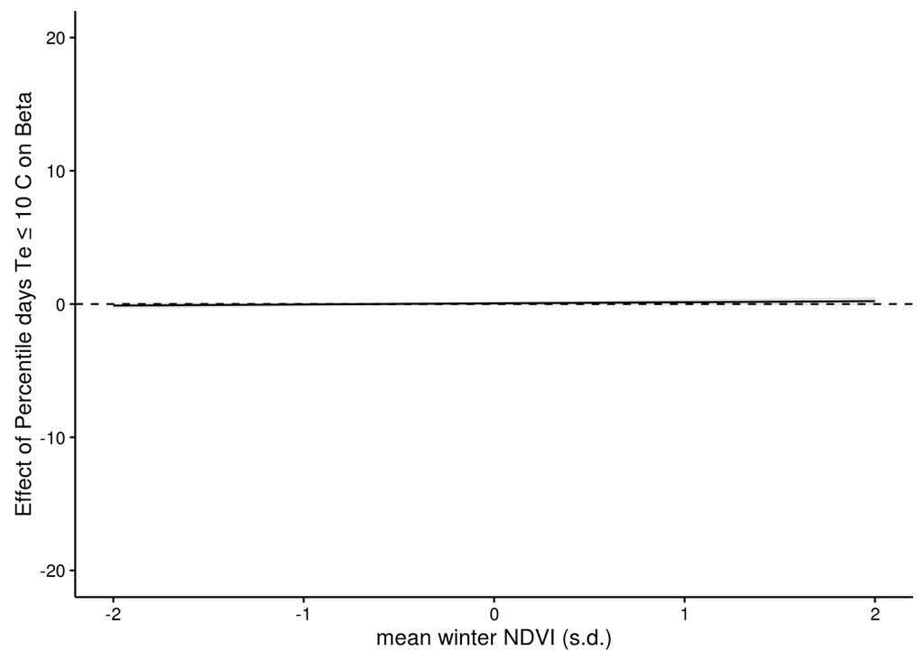

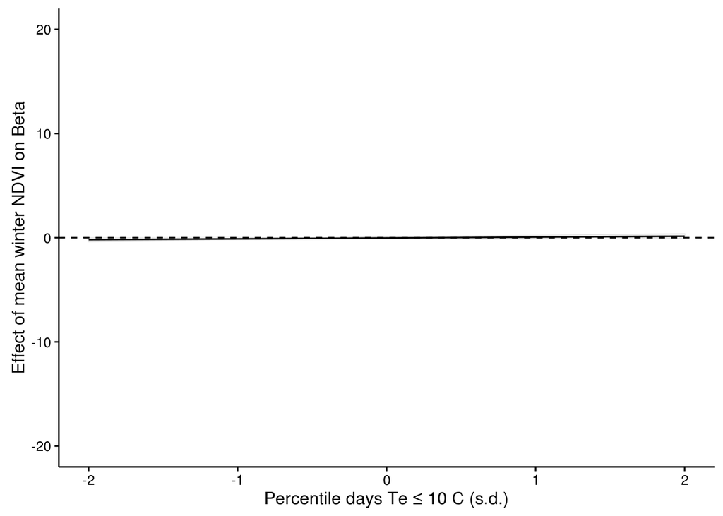

[figure not shown]

```r
detach(yearly.weight.stat)
```

## Appendix

### Site specific plots

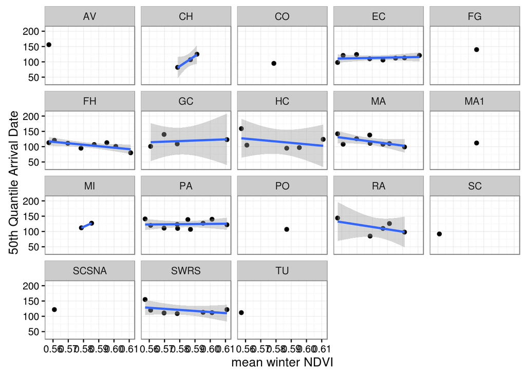

But winters with more low temperature days (<= 10 C) did not show a strong relationship with migration arrival dates across sites:

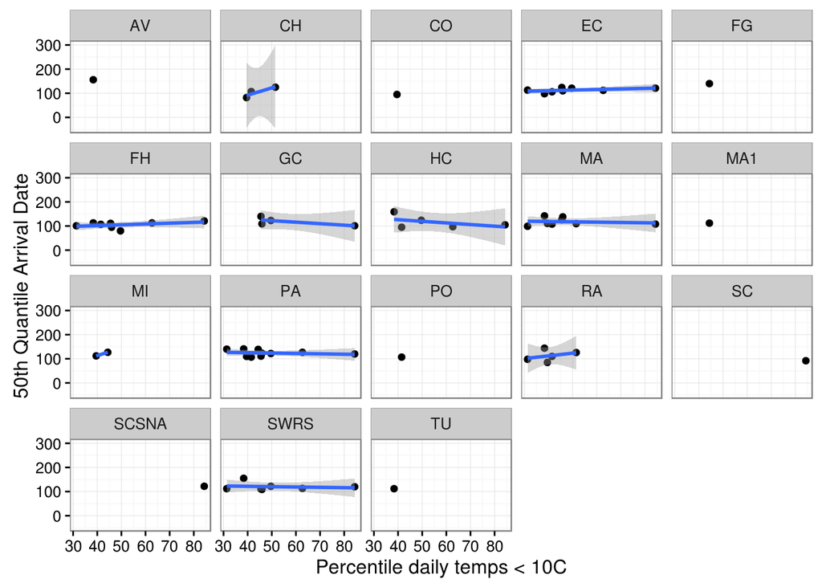

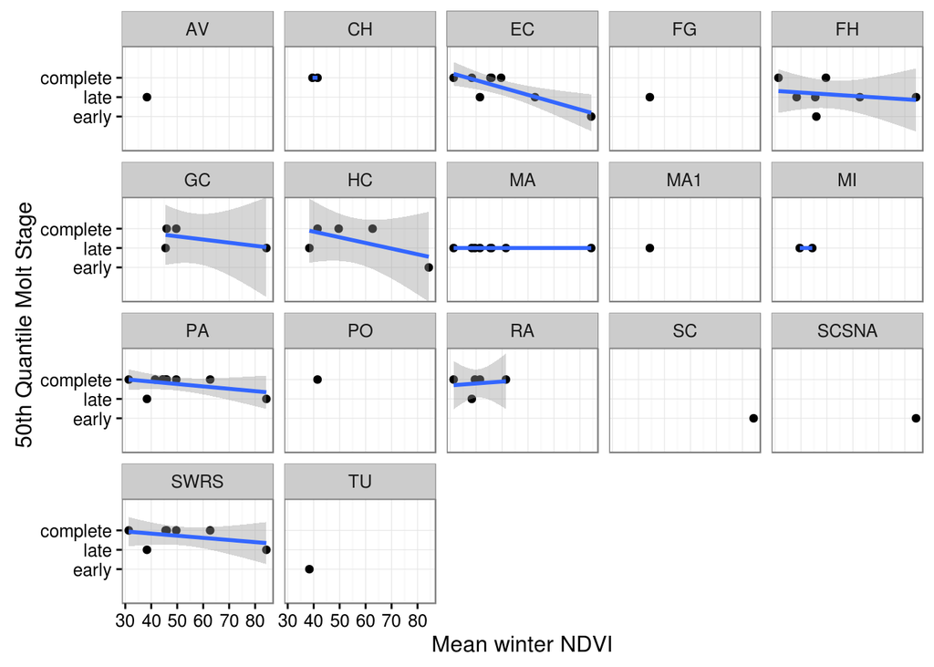

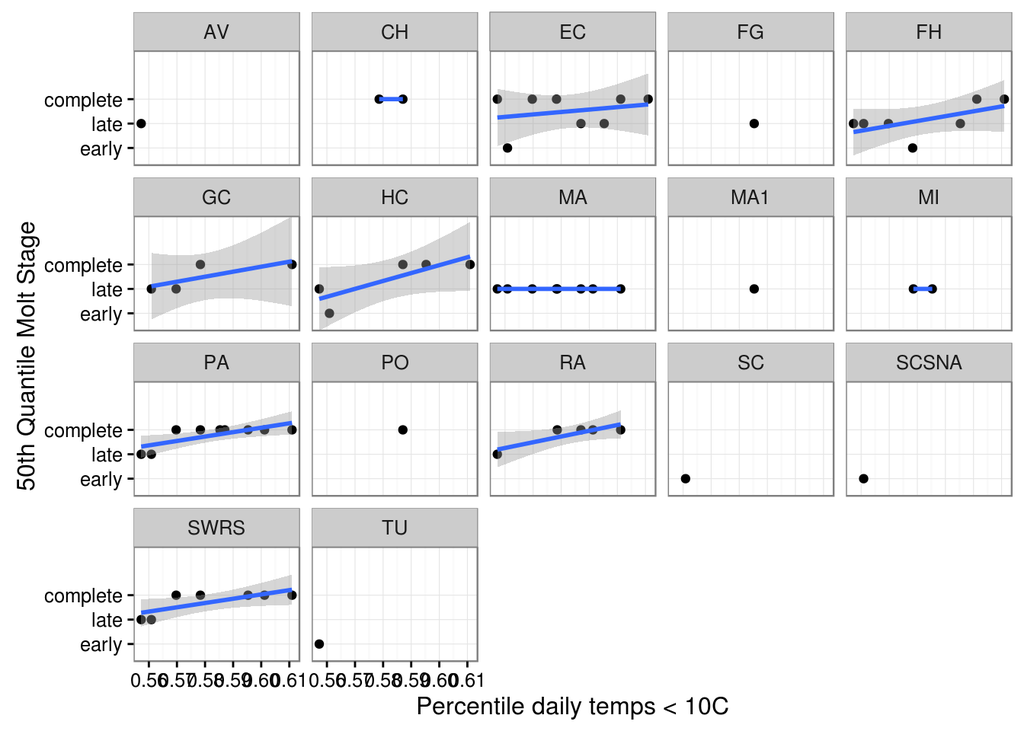

There were not strong correlations among the mass and fat variables for migrating BTHU and the winter environmental predictor variables. This is likely because hummingbird’s energetic needs and expenditures are such that their fat and body mass are likely changing on a temporal scale of hours to days instead of season to season:

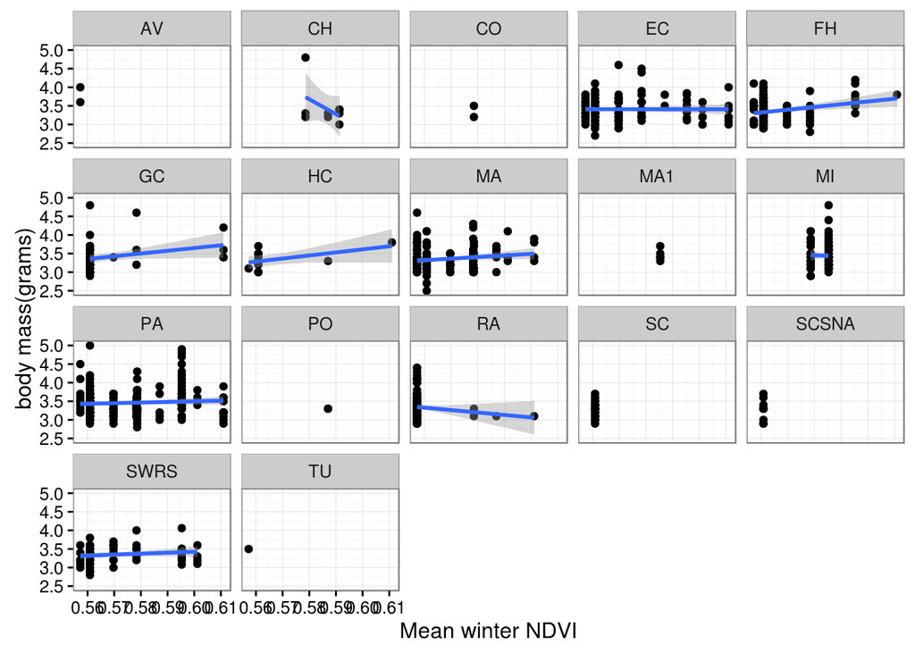

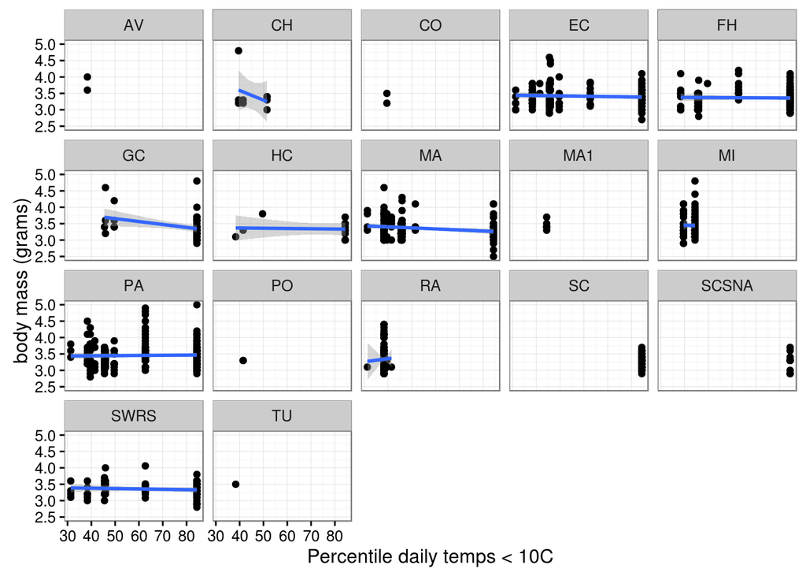

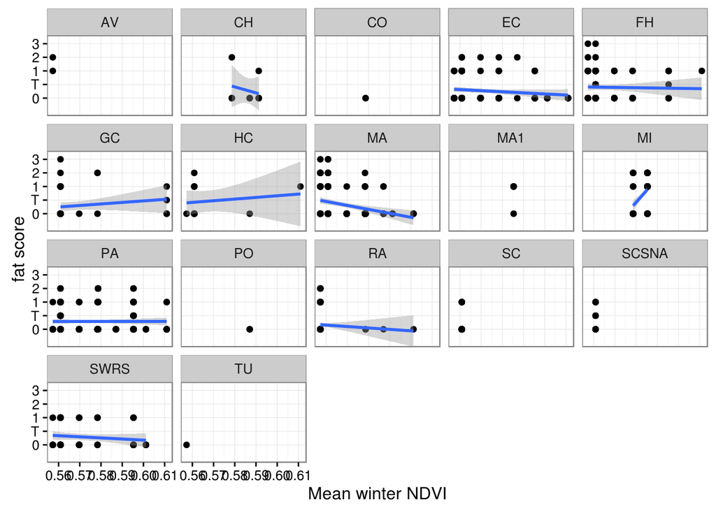

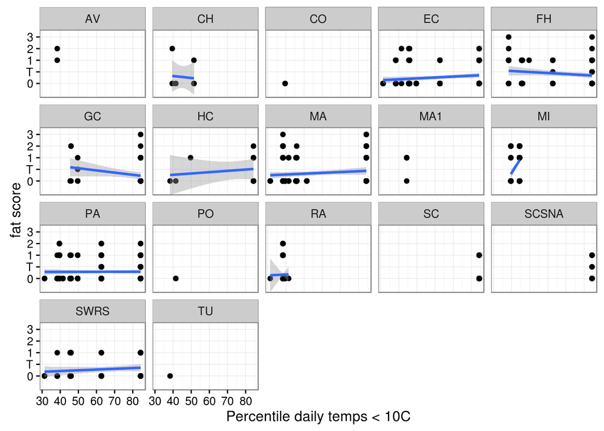

### Molt as 14 Classes

We originally used all 14 classes of molt for the main model, but a reviewer suggested that a simplified look at molt (early, late, complete) might actually be more useful. The simplified version is now included in the main manuscript, but the detailed version is here. Results are similar, but the best model flips from additive (D_R for 3 molt classes) to interactive (DR for 14 molt classes).

**Molt as 14 classes:** We used the function (mod.evaluation.R) to evaluate [hierarchical models](http://www.quantpsy.org/interact/interactions.htm) of **median molt stage (50th quantile)** as a linear function of annual physiological demand (percentile daily Te < 10 C) and resource availability (mean winter NDVI), allowing for a random intercept associated with ‘site’. Here, we treat molt stage as ‘binomial’ since the distance between categories is not assumed to be constant. See the *methods* section of the manuscript for more details.

```r
# run the model using ALL the molt classes
attach(yearly.molt.stat)
mod.evaluation(yname='MOLT.quant.50', centering='CGM', standardisation=T,
               ordered.fac.treatment = "as.binomial", log.D=T,
               R="winterNDVI", D="yearly.Te.10C.q")
```

```
## samples will be weighted by 'n.birds' in model calibration
## DEMAND variable will be log-transformed
##
## Correlation between D and R (after transform and or subset):
##
##  Pearson's product-moment correlation
##
## data:  D and R
## t = -2.115, df = 62, p-value = 0.03845
## alternative hypothesis: true correlation is not equal to 0
## 95 percent confidence interval:
##  -0.47493793 -0.01453099
## sample estimates:
##        cor
## -0.2594137
##
##
##  MOLT.quant.50  is an ordered factor. options are to treat as numeric or in a binomial fashion !!!
## MOLT.quant.50  is an ordered factor and will be converted to a count table !!!
##
## Predictor variables were centered at the grand mean (CGM)
##
## Predictor variables were standardised using grand sd
```

```
## Conditional effects of predictors in full model, i.e. including R*D interaction
```

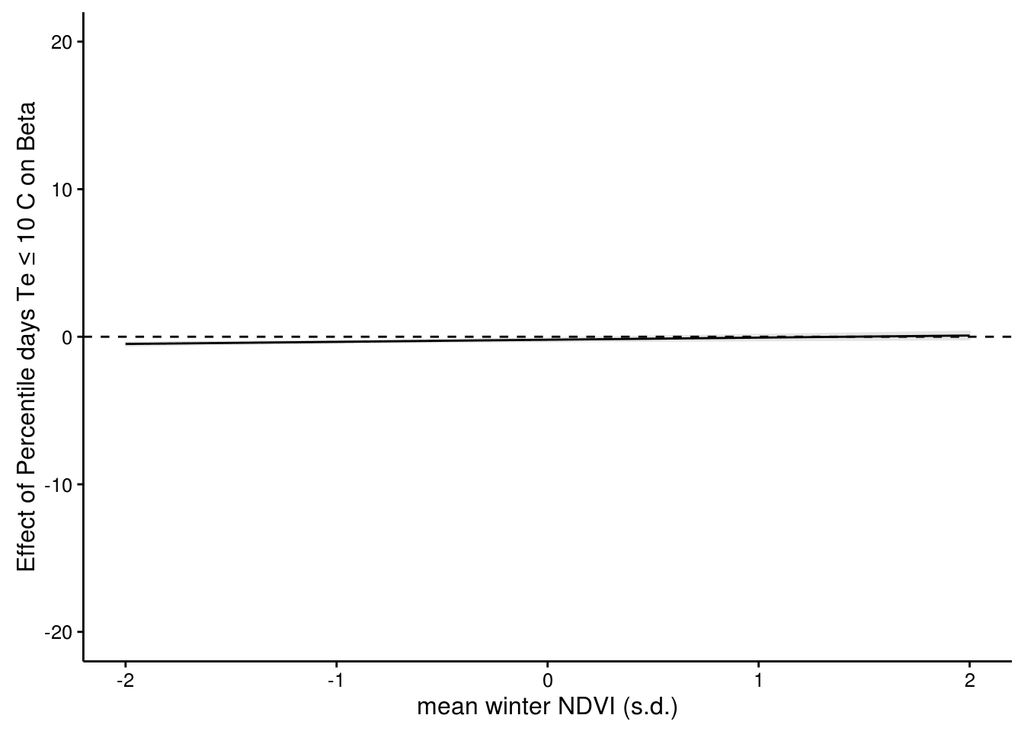

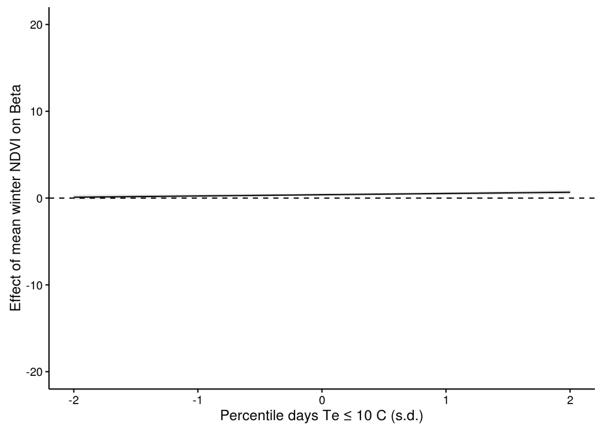

```
## Calculating psuedo R2 for binomial response variable
## Calculating Lefcheck (Nakagawa & Schielzeth) marginal and conditional R2
## AIC of best model: 2841.071
## There were 128 observations and 17 groups in the model.
## Model evaluation completed and tabulated:
```

```
## [[1]]
##         mod.name dAICc.lib dAICCc.con df A.weight.lib D_low D_high R_low
## mod.DR    mod.DR       0.0        0.0  5            1 -0.31  -0.10  0.30
## mod.D_R  mod.D_R       7.6        5.8  4            0 -0.40  -0.28  0.34
## mod.D      mod.D     112.3      109.3  3            0 -0.52  -0.41    NA
## mod.R      mod.R     126.3      123.3  3            0    NA     NA  0.52
## mod.0      mod.0     379.0      375.2  2            0    NA     NA    NA
##         R_high DR_low DR_high D_est R_est DR_est       SE_D       SE_R
## mod.DR    0.47   0.06    0.23 -0.20  0.39   0.14 0.05261993 0.04381222
## mod.D_R   0.51     NA      NA -0.34  0.43     NA 0.05261993 0.04237591
## mod.D       NA     NA      NA -0.47    NA     NA 0.02919802         NA
## mod.R     0.68     NA      NA    NA  0.60     NA         NA 0.03970942
## mod.0       NA     NA      NA    NA    NA     NA         NA         NA
##            SE_DR    pseudR2 MarginalR2 ConditonalR2
## mod.DR  0.044529 0.11993824 0.05933995    0.3214492
## mod.D_R       NA 0.11685108 0.07534016    0.3347826
## mod.D         NA 0.08358110 0.04475570    0.3201221
## mod.R         NA 0.07924509 0.06816011    0.3775658
## mod.0         NA 0.00000000 0.00000000    0.3700479
##
## [[2]]
```

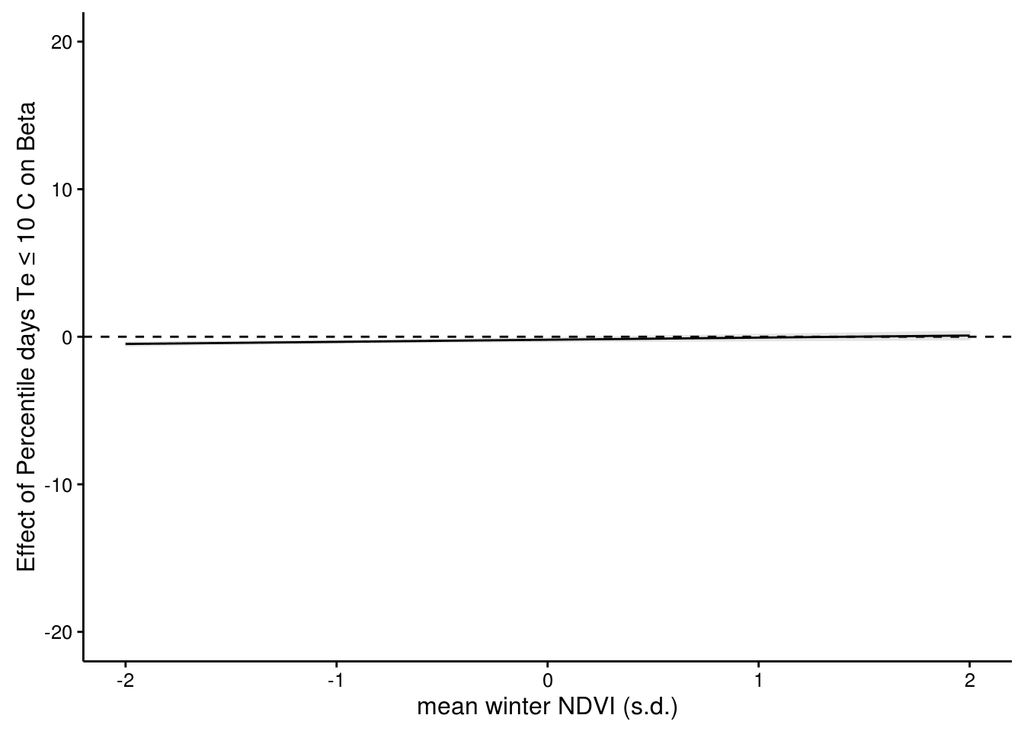

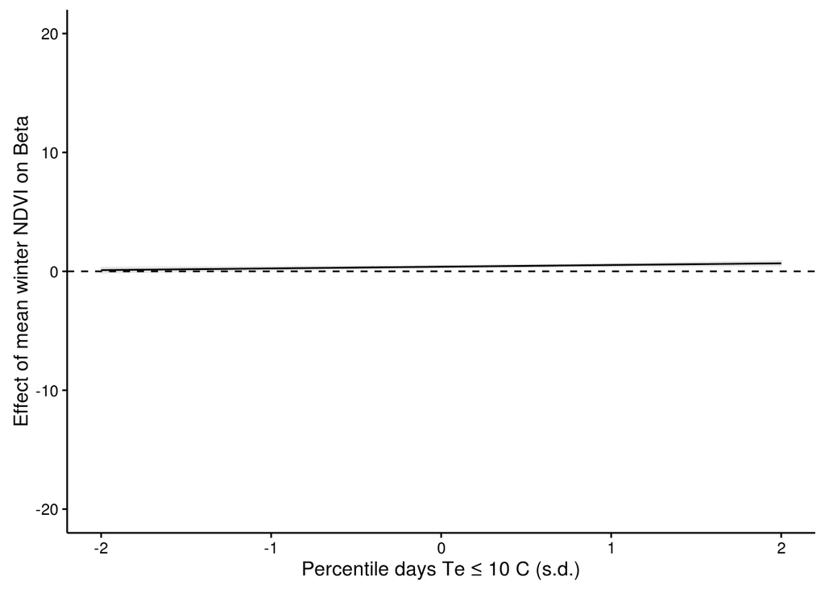

```r
detach(yearly.molt.stat)
```

### Biological Response Models for the 25th and 75th quantiles of the variables

We used a function (mod.evaluation.R) to evaluate [hierarchical models](http://www.quantpsy.org/interact/interactions.htm) of the biological response variables (arrival, molt, mass, and fat) as a linear function of annual physiological demand (percentile daily Te < 10 C) and resource availability (mean winter NDVI), allowing for a random intercept associated with ‘site’. Here, we present the results using the 25th and 75th quantiles of the response data (Arrival and Molt), rather than the 50th quantile (median) results we present in the main manuscript.

**25th Quantile Arrival**

```r
#add column for 25th quartile julian day of year
yearly.arrival.stat$jday.25 <- yday(yearly.arrival.stat$ARR.quant.25)

attach(yearly.arrival.stat)

mod.evaluation(yname='jday.25', centering='CGM', stand=T, ordered.fac.treatment = "as.num", log.D=T, R="winterNDVI")
```

```
## samples will be weighted by 'n.birds' in model calibration
## DEMAND variable will be log-transformed
##
## Correlation between D and R (after transform and or subset):
##
##  Pearson's product-moment correlation
##
## data:  D and R
## t = -2.1312, df = 66, p-value = 0.0368
## alternative hypothesis: true correlation is not equal to 0
## 95 percent confidence interval:
##  -0.46409827 -0.01631334
## sample estimates:
##        cor
## -0.2537515
##
##
## Predictor variables were centered at the grand mean (CGM)
##
## Predictor variables were standardised using grand sd
```

```
## Conditional effects of predictors in full model, i.e. including R*D interaction
```

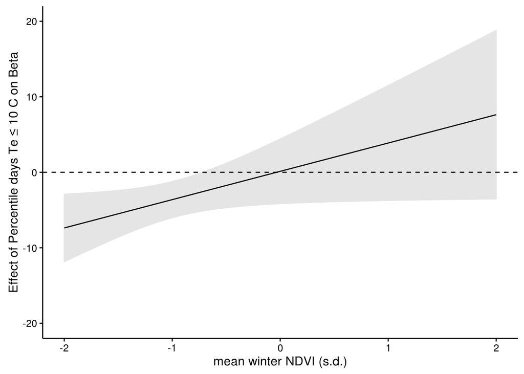

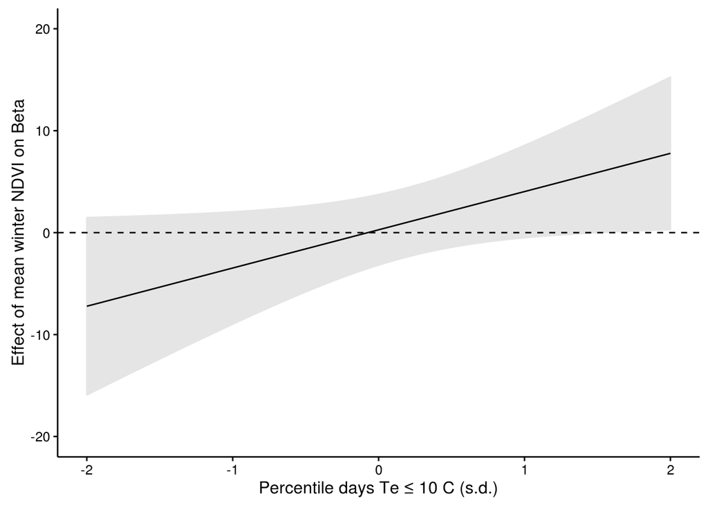

```
## Calculating fixed-effects R2
## Calculating psuedo R2 for numeric response variable
## Calculating Lefcheck (Nakagawa & Schielzeth) marginal and conditional R2
## AIC of best model: 580.2336
## There were 68 observations and 18 groups in the model.
## Model evaluation completed and tabulated:
```

```
## [[1]]
##         mod.name dAICc.lib dAICCc.con df A.weight.lib D_low D_high R_low
## mod.DR    mod.DR       0.0        0.0  6            1 -4.16   4.41 -3.19
## mod.D_R  mod.D_R       4.4        2.2  5            0 -6.15  -1.40 -2.41
## mod.D      mod.D       5.4        1.6  4            0 -6.24  -1.79    NA
## mod.R      mod.R      11.1        7.2  4            0    NA     NA -0.88
## mod.0      mod.0      13.8        8.9  3            0    NA     NA    NA
##         R_high DR_low DR_high D_est R_est DR_est     SE_D     SE_R
## mod.DR    3.75   0.08    7.42  0.13  0.28   3.75 2.185806 1.770436
## mod.D_R   4.44     NA      NA -3.78  1.01     NA 2.185806 1.746618
## mod.D       NA     NA      NA -4.02    NA     NA 1.134167       NA
## mod.R     5.89     NA      NA    NA  2.51     NA       NA 1.726145
## mod.0       NA     NA      NA    NA    NA     NA       NA       NA
##            SE_DR fixefR2     pseudR2  MarginalR2 ConditonalR2
## mod.DR  1.873207      24  0.13155894 0.007056605  0.009507973
## mod.D_R       NA      15 -0.01340731 0.006580866  0.006580866
## mod.D         NA      16  0.00602971 0.006220010  0.006220010
## mod.R         NA      12 -0.02660988 0.002436516  0.012591671
## mod.0         NA      14  0.02997706 0.000000000  0.012196868
##
## [[2]]
```

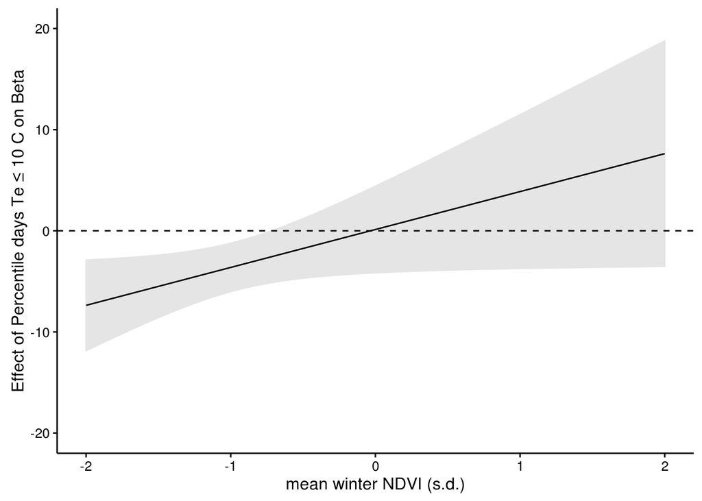

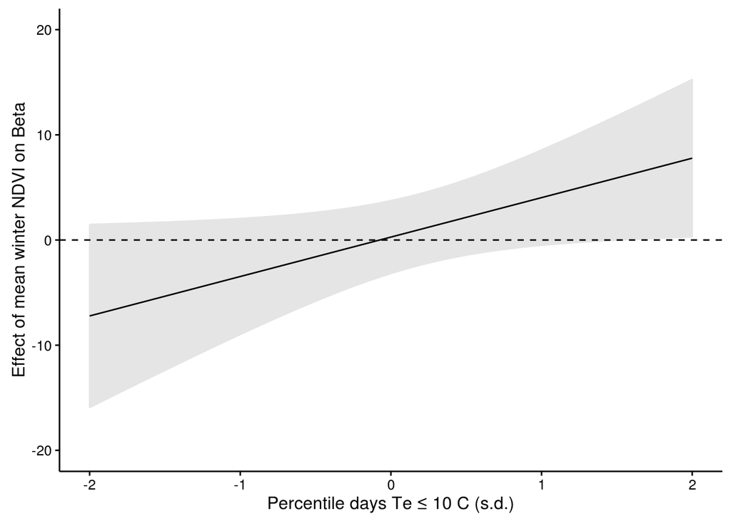

```r
detach(yearly.arrival.stat)
```

**25th Quantile Molt**

```r
attach(yearly.molt3.stat)
#http://www.quantpsy.org/interact/interactions.htm
mod.evaluation(yname='MOLT.quant.25', centering='CGM', stand=T,
               ordered.fac.treatment = "as.binomial",
               log.D=T, R="winterNDVI", D="yearly.Te.10C.q")
```

```
## samples will be weighted by 'n.birds' in model calibration
## DEMAND variable will be log-transformed
##
## Correlation between D and R (after transform and or subset):
##
##  Pearson's product-moment correlation
##
## data:  D and R
## t = -2.115, df = 62, p-value = 0.03845
## alternative hypothesis: true correlation is not equal to 0
## 95 percent confidence interval:
##  -0.47493793 -0.01453099
## sample estimates:
##        cor
## -0.2594137
##
##
##  MOLT.quant.25  is an ordered factor. options are to treat as numeric or in a binomial fashion !!!
## MOLT.quant.25  is an ordered factor and will be converted to a count table !!!
##
## Predictor variables were centered at the grand mean (CGM)
##
## Predictor variables were standardised using grand sd
```

```
## Conditional effects of predictors in full model, i.e. including R*D interaction
```

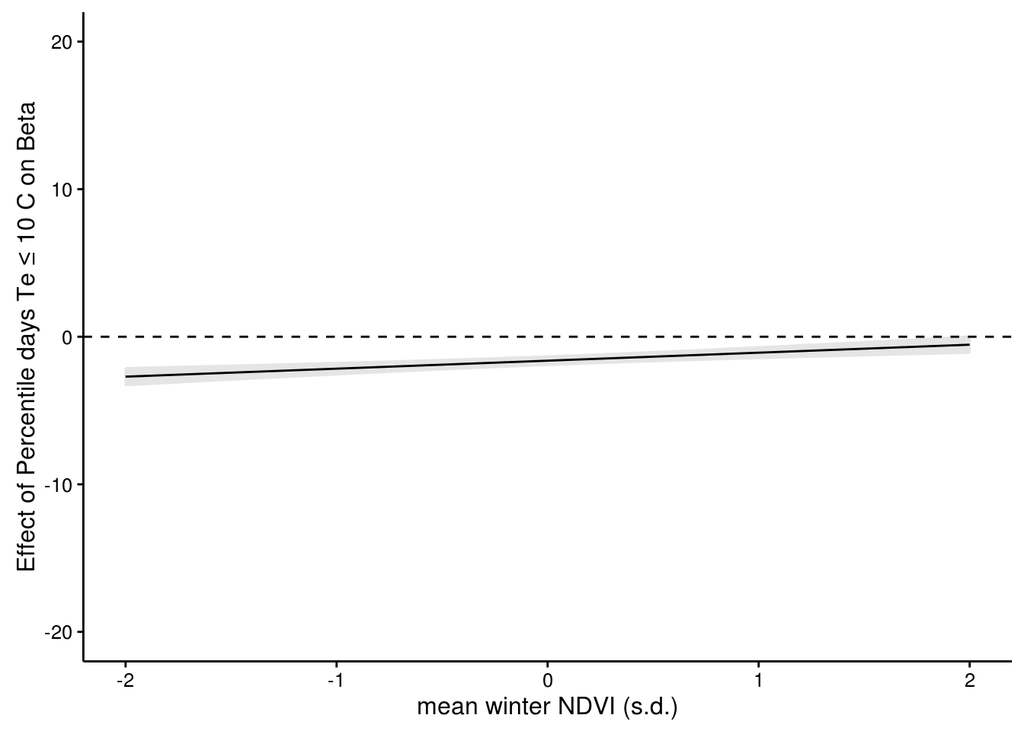

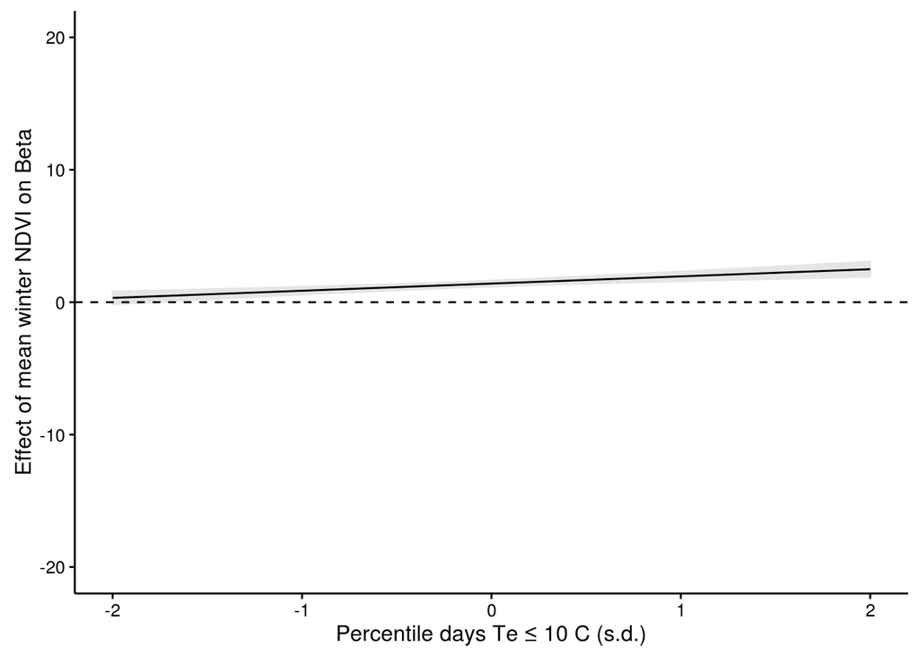

```
## Calculating psuedo R2 for binomial response variable
## Calculating Lefcheck (Nakagawa & Schielzeth) marginal and conditional R2
## AIC of best model: 1046.559
## There were 128 observations and 17 groups in the model.
## Model evaluation completed and tabulated:
```

```
## [[1]]
##         mod.name dAICc.lib dAICCc.con df A.weight.lib D_low D_high R_low
## mod.DR    mod.DR       0.0        0.0  5            1 -1.92  -1.32  1.18
## mod.D_R  mod.D_R      18.6       16.8  4            0 -2.03  -1.53  1.23
## mod.D      mod.D     327.5      324.5  3            0 -1.57  -1.30    NA
## mod.R      mod.R     471.0      468.1  3            0    NA     NA  1.26
## mod.0      mod.0     946.3      942.6  2            0    NA     NA    NA
##         R_high DR_low DR_high D_est R_est DR_est       SE_D       SE_R
## mod.DR    1.63    0.3    0.78 -1.62  1.41   0.54 0.15198771 0.11524242
## mod.D_R   1.64     NA      NA -1.78  1.43     NA 0.15198771 0.10348100
## mod.D       NA     NA      NA -1.43    NA     NA 0.07080729         NA
## mod.R     1.54     NA      NA    NA  1.40     NA         NA 0.07233959
## mod.0       NA     NA      NA    NA    NA     NA         NA         NA
##             SE_DR   pseudR2 MarginalR2 ConditonalR2
## mod.DR  0.1233127 0.4790452  0.6660372    0.6867851
## mod.D_R        NA 0.4685351  0.6445679    0.6762687
## mod.D          NA 0.3121333  0.3535649    0.4351081
## mod.R          NA 0.2399862  0.2755930    0.5368610
## mod.0          NA 0.0000000  0.0000000    0.4794085
##
## [[2]]
```

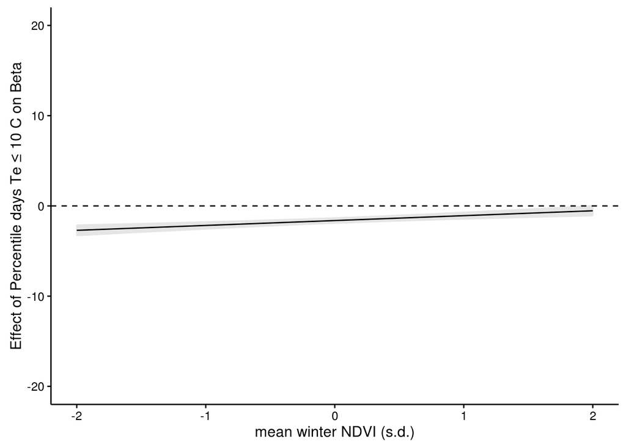

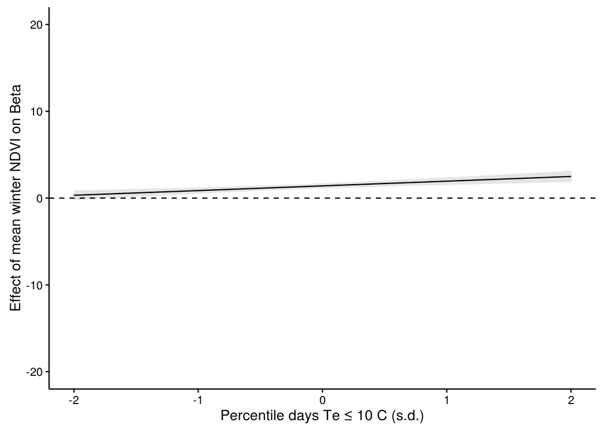

```r
detach(yearly.molt3.stat)
```

**75th Quantile Arrival**

```r
#add column for 25th quartile julian day of year
yearly.arrival.stat$jday.75 <- yday(yearly.arrival.stat$ARR.quant.75)

attach(yearly.arrival.stat)
mod.evaluation(yname='jday.75', centering='CGM', stand=T,
               ordered.fac.treatment = "as.num",
               log.D=T, R="winterNDVI")
```

```
## samples will be weighted by 'n.birds' in model calibration
## DEMAND variable will be log-transformed
##
## Correlation between D and R (after transform and or subset):
##
##  Pearson's product-moment correlation
##
## data:  D and R
## t = -2.1312, df = 66, p-value = 0.0368
## alternative hypothesis: true correlation is not equal to 0
## 95 percent confidence interval:
##  -0.46409827 -0.01631334
## sample estimates:
##        cor
## -0.2537515
##
##
## Predictor variables were centered at the grand mean (CGM)
##
## Predictor variables were standardised using grand sd
```

```
## Conditional effects of predictors in full model, i.e. including R*D interaction
```

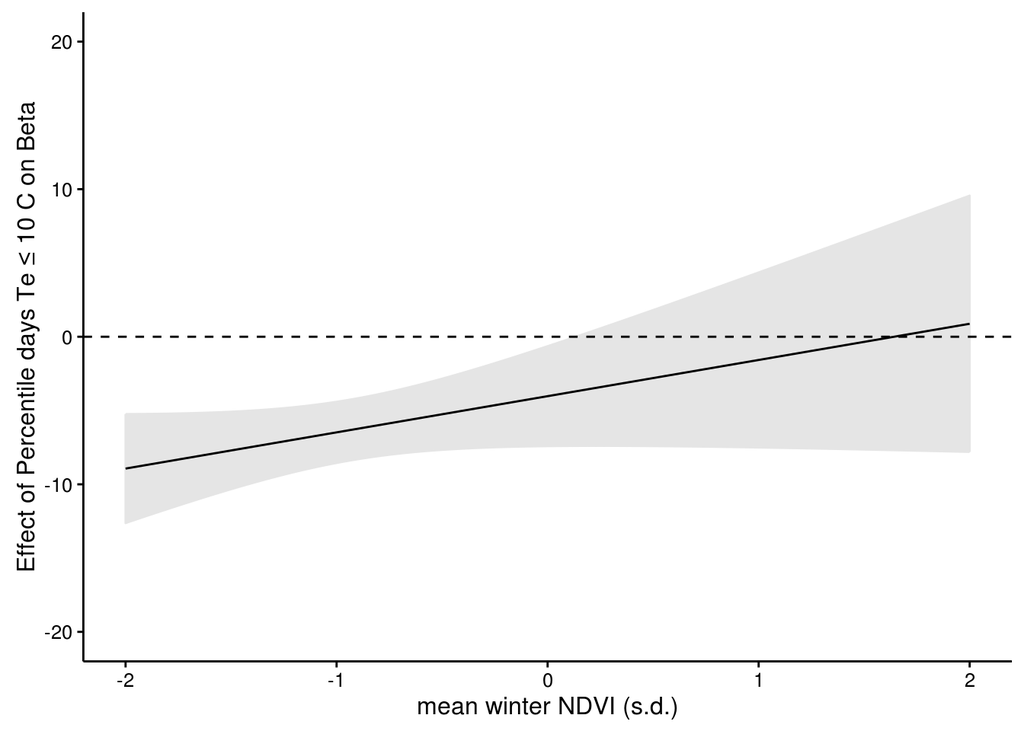

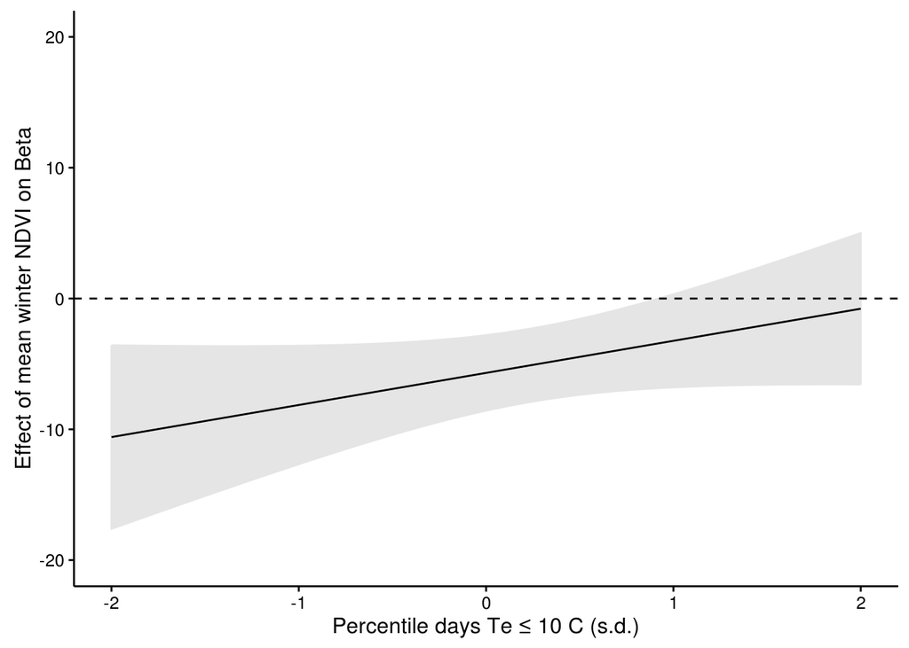

```
## Calculating fixed-effects R2
## Calculating psuedo R2 for numeric response variable
## Calculating Lefcheck (Nakagawa & Schielzeth) marginal and conditional R2
## AIC of best model: 555.3699
## There were 68 observations and 18 groups in the model.
## Model evaluation completed and tabulated:
```

```
## [[1]]
##         mod.name dAICc.lib dAICCc.con df A.weight.lib D_low D_high R_low
## mod.DR    mod.DR       0.0        0.0  6            1 -7.42  -0.64 -8.57
## mod.D_R  mod.D_R       3.0        0.7  5            0 -8.42  -4.23 -7.94
## mod.D      mod.D      14.2       10.3  4            0 -7.19  -3.06    NA
## mod.R      mod.R      30.4       26.6  4            0    NA     NA -5.01
## mod.0      mod.0      32.3       27.4  3            0    NA     NA    NA
##         R_high DR_low DR_high D_est R_est DR_est     SE_D     SE_R
## mod.DR   -2.80  -0.42    5.33 -4.03 -5.69   2.45 1.729739 1.473861
## mod.D_R  -2.25     NA      NA -6.33 -5.09     NA 1.729739 1.452641
## mod.D       NA     NA      NA -5.12    NA     NA 1.053845       NA
## mod.R     1.27     NA      NA    NA -1.87     NA       NA 1.600726
## mod.0       NA     NA      NA    NA    NA     NA       NA       NA
##            SE_DR fixefR2   pseudR2  MarginalR2 ConditonalR2
## mod.DR  1.466775      49 0.3426134 0.034242264   0.05649071
## mod.D_R       NA      48 0.3322455 0.032355121   0.05395201
## mod.D         NA      28 0.1468953 0.014280522   0.02611856
## mod.R         NA      31 0.1819849 0.001641493   0.03918038
## mod.0         NA      22 0.1068901 0.000000000   0.03326502
##
## [[2]]
```

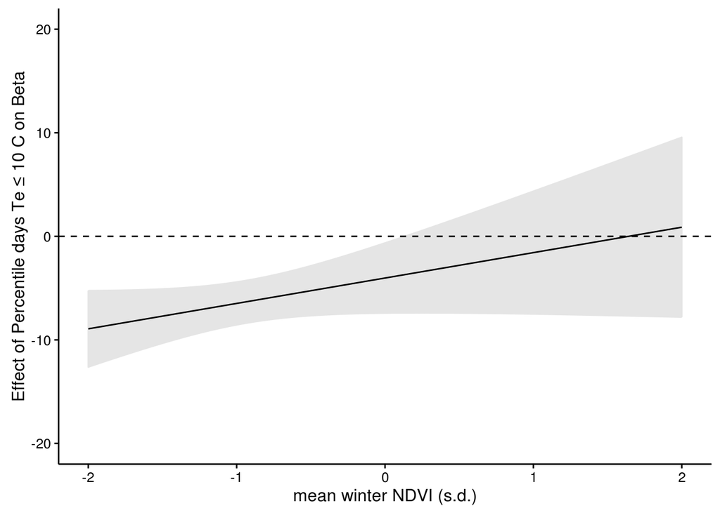

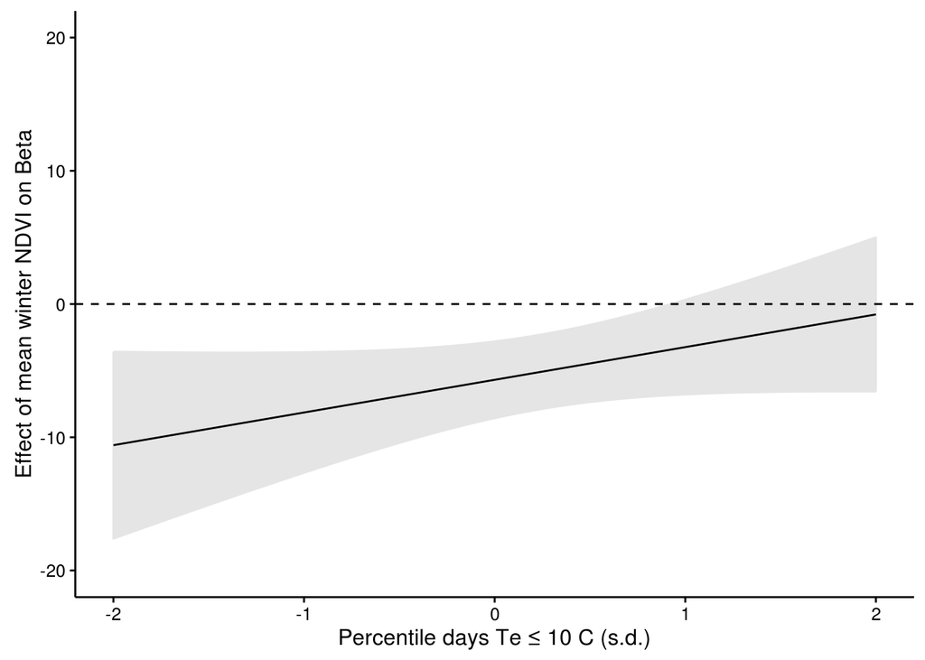

```r
detach(yearly.arrival.stat)
```

**75th Quantile Molt**

```r
attach(yearly.molt3.stat)
mod.evaluation(yname='MOLT.quant.75', centering='CGM', stand=T,
               ordered.fac.treatment = "as.binomial",
               log.D=T, R="winterNDVI", D="yearly.Te.10C.q")
```

```
## samples will be weighted by 'n.birds' in model calibration
## DEMAND variable will be log-transformed
##
## Correlation between D and R (after transform and or subset):
##
##  Pearson's product-moment correlation
##
## data:  D and R
## t = -2.115, df = 62, p-value = 0.03845
## alternative hypothesis: true correlation is not equal to 0
## 95 percent confidence interval:
##  -0.47493793 -0.01453099
## sample estimates:
##        cor
## -0.2594137
##
##
##  MOLT.quant.75  is an ordered factor. options are to treat as numeric or in a binomial fashion !!!
## MOLT.quant.75  is an ordered factor and will be converted to a count table !!!
##
## Predictor variables were centered at the grand mean (CGM)
##
## Predictor variables were standardised using grand sd
```

```
## Conditional effects of predictors in full model, i.e. including R*D interaction
```

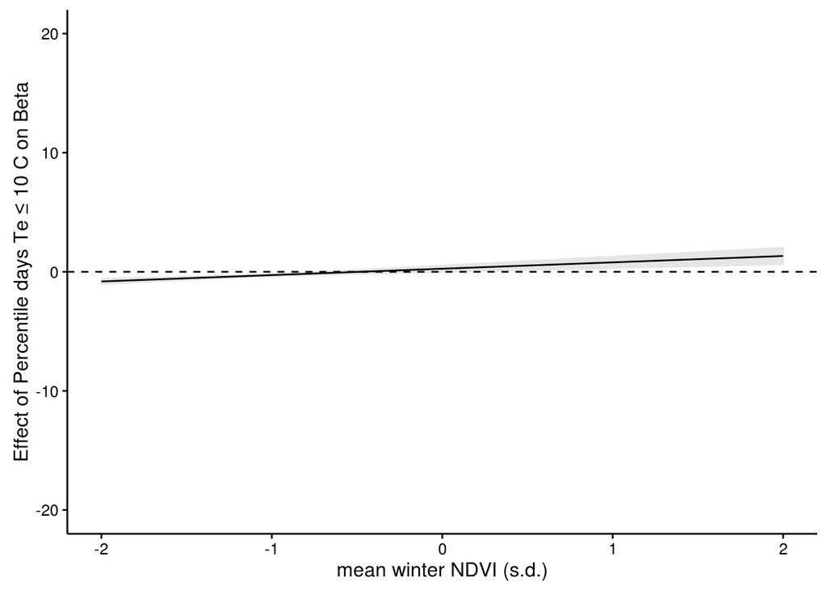

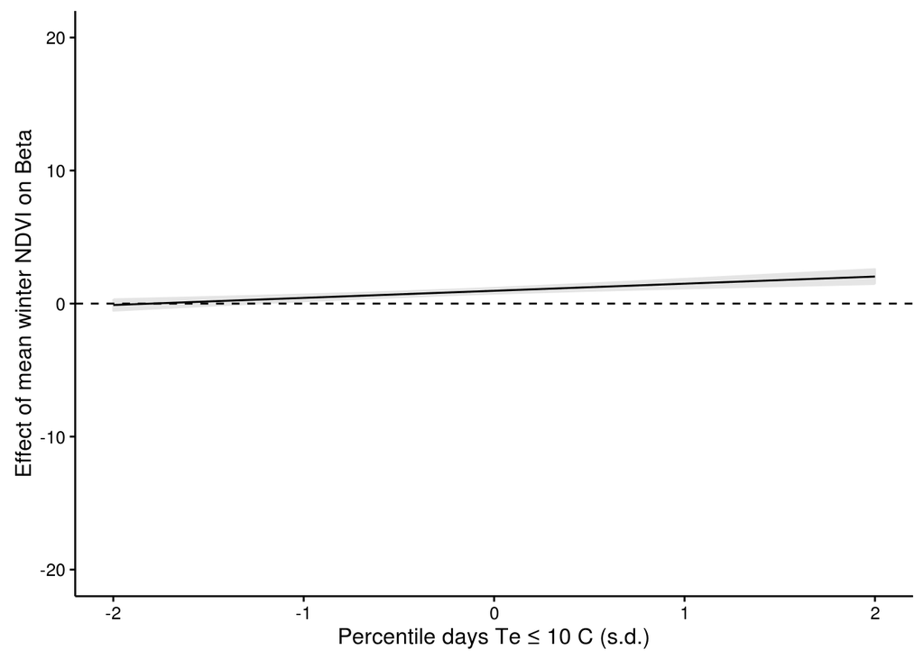

```
## Calculating psuedo R2 for binomial response variable
## Calculating Lefcheck (Nakagawa & Schielzeth) marginal and conditional R2
## AIC of best model: 1683.31
## There were 128 observations and 17 groups in the model.
## Model evaluation completed and tabulated:
```

```
## [[1]]
##         mod.name dAICc.lib dAICCc.con df A.weight.lib D_low D_high R_low
## mod.DR    mod.DR       0.0        0.0  5            1 -0.01   0.52  0.74
## mod.D_R  mod.D_R      18.9       17.1  4            0 -0.43  -0.22  0.75
## mod.R      mod.R      55.4       52.4  3            0    NA     NA  0.92
## mod.D      mod.D     133.0      130.0  3            0 -0.66  -0.45    NA
## mod.0      mod.0     254.4      250.6  2            0    NA     NA    NA
##         R_high DR_low DR_high D_est R_est DR_est       SE_D      SE_R
## mod.DR    1.18   0.31    0.76  0.26  0.96   0.53 0.13491254 0.1128457
## mod.D_R   1.15     NA      NA -0.33  0.95     NA 0.13491254 0.1016472
## mod.R     1.30     NA      NA    NA  1.11     NA         NA 0.0979680
## mod.D       NA     NA      NA -0.56    NA     NA 0.05387834        NA
## mod.0       NA     NA      NA    NA    NA     NA         NA        NA
##             SE_DR    pseudR2 MarginalR2 ConditonalR2
## mod.DR  0.1140039 0.13503075 0.22993517   0.33543626
## mod.D_R        NA 0.12405520 0.23066171   0.34775178
## mod.R          NA 0.10399641 0.25073342   0.33126093
## mod.D          NA 0.06389032 0.07445846   0.20609077
## mod.0          NA 0.00000000 0.00000000   0.05702193
##
## [[2]]
```

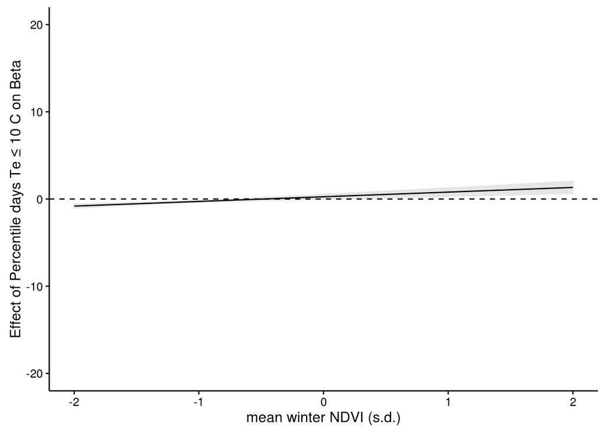

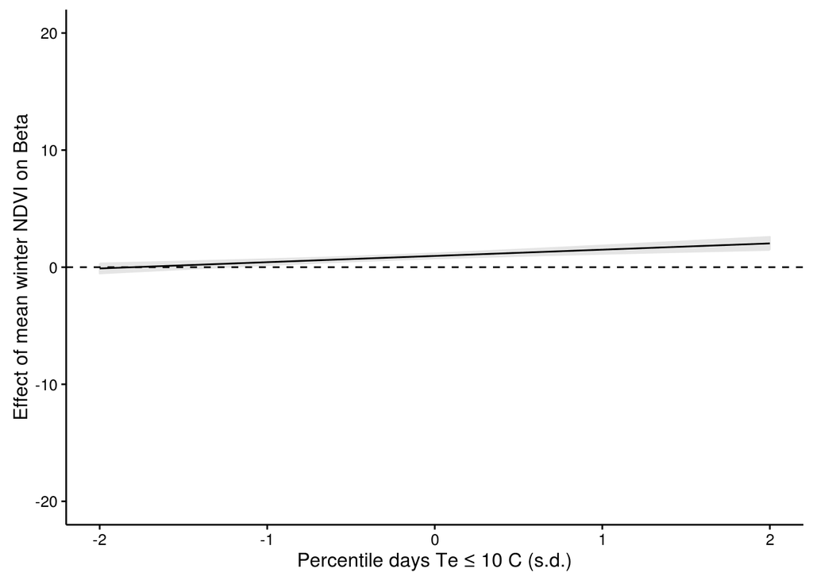

```r
detach(yearly.molt3.stat)
```